# Analyzing 45 Million Amazon.com user ratings

**By: Michael Di Amore (mad2271), Aravind Sadagopan (as5195), Amir Rahmani (ar3717)**

### 1. Introduction

The Amazon review data set is a semi-structured multi-table json file of reviews and ratings of various amazon products across multiple categories. For the purpose of this project we leveraged Amazon EC2 to preprocess the entire dataset (python script used for preprocessing data included) to restrict our focus to following categories.

- Books
- Electronics
- Cellphone and Accessories
- Automotive
- Baby
- Beauty
- Tools and Home Improvement
- Clothing, Shoes & Jewelry

Our intention beyond the obvious data engineering and feature extraction challenges is to answer few motivating questions like:-

1. Does average product rating converge to 3 stars or is it concentrated at extremes as only excited or unhappy customers take time to review?
2. Do ratings and product categories have some correlation? For example, do Baby products have extreme ratings compared other categories as they tend to have higher expectations/concerns towards products?
3. Do reviewer activity correlate with festival shopping activity (Black Friday, Christmas etc.) or is there a lag effect?
4. What is the average price of a product that gets extreme reviews? Does the price of product have an effect on the sentiment of the customer?

##### *Citation*

*Image-based recommendations on styles and substitutes J. McAuley, C. Targett, J. Shi, A. van den Hengel SIGIR, 2015*

*Inferring networks of substitutable and complementary products J. McAuley, R. Pandey, J. Leskovec Knowledge Discovery and Data Mining, 2015)*

### 2. Team

- Michael Di Amore (mad2271)
- Aravind Sadagopan (as5195)
- Amir Rahmani (ar3717)

The nature of the project required us to be highly collaborative. Beyond the preprocessing of raw data, the team did collaborate on every aspect on the project including the final report. The team members often analyzed the data independently and we met once a week to share our findings/analysis and to decide on which aspects of our analysis we wanted to include/further analyze.

### 3. Analysis of Data Quality

#### 3.1 Raw Data to Project Dataset

The following workflow illustrates the conversion pipeline from raw data to the final dataset used for this project

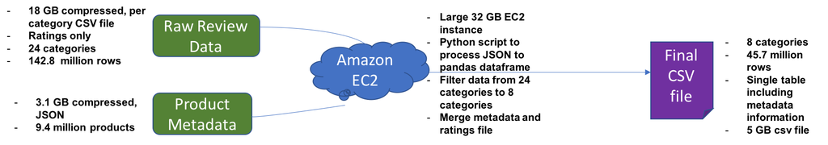

Data Preprocessing pipeline

**Python Preprocessing code**

```
import os
import glob
import csv

import pandas as pd
import gzip

def parse(path):
    g = gzip.open(path, 'rb')
    for l in g:
        yield eval(l)

def getDF(path):
    i = 0
    df = {}
    for d in parse(path):
        df[i] = d
        i += 1
    return pd.DataFrame.from_dict(df, orient='index')

# Read Metadata JSON file to metadata csv
with open('metadata.csv','w') as meta:
    meta_writer = csv.writer(meta)
    meta_writer.writerow(['asin', 'title', 'price'])
    for review in parse("metadata.json.gz"):
        if 'asin' in review:
            asin = review['asin']
        else:
            continue
        if 'title' in review:
            title = review['title']
        else:
            title = 'NA'
        if 'price' in review:
            price = review['price']
        else:
            price = 'NA'
        meta_writer.writerow([asin, title, price])

metdata = pd.read_csv('metadata.csv')
cat_files = glob.glob("./reviewdata/ratings*.csv")
for filename in cat_files:
    cat_data = pd.read_csv(filename, header=None,
                        names=['uid','asin','rating','timestamp'])
    cat_out = cat_data.merge(metdata)
    category_name = os.path.basename(filename)
    cat_out.to_csv('output/' + category_name,index=False)

want_header = True
out_filename = "./output/amazon_ratings_full.csv"

if os.path.exists(out_filename):
    os.remove(out_filename)

read_files = glob.glob("./output/*.csv")

with open(out_filename, "w") as outfile:
    for filename in read_files:
        category = os.path.basename(filename).split('.')[0]
        with open(filename) as infile:
            if want_header:
                outfile.write('{},Category\n'.format(next(infile).strip()))
                want_header = False
            else:
                next(infile)
            for line in infile:
                outfile.write('{},{}\n'.format(line.strip(), category))
```

#### 3.2 Data Schema

The final schema for the merged data for ratings is illustrated below

| ï..No. | Field.Name | Description |
| --- | --- | --- |
| 1 | uid | UserID of Reviewer |
| 2 | asin | Product ID |
| 3 | ratings | Ratings (1 to 5) |
| 4 | timestamp | Unix timestamp of review |
| 5 | title | Product Name |
| 6 | price | Product price |
| 7 | category | Product category (one of 8 outlined above) |

#### 3.3 Total Rows & Missing Values in Data

The dataset has 45.7 million ratings and has complete values for all fields except for the price and title of certain products highlighted below

Summary of Ratings

| uid | asin | rating | timestamp | title | price | Category | date |
| --- | --- | --- | --- | --- | --- | --- | --- |
| 45766137 | 45766137 | 45766137 | 45766137 | 45766137 | 45766137 | 45766137 | 45766137 |

Missing Value Summary

| uid | asin | rating | timestamp | title | price | Category | date |
| --- | --- | --- | --- | --- | --- | --- | --- |
| 0 | 0 | 0 | 0 | 3496004 | 5853208 | 0 | 0 |

#### 3.4 Data Summary

##### 3.4.1 Distribution of Ratings

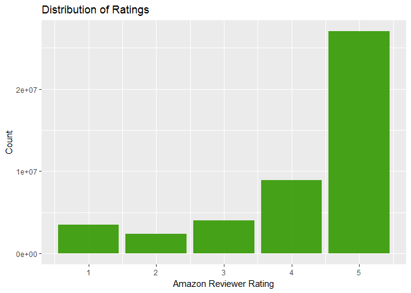

##### 3.4.2 Distribution of Categories

Books dominate the ratings in this dataset followed by Electronics. Baby products have the fewest ratings

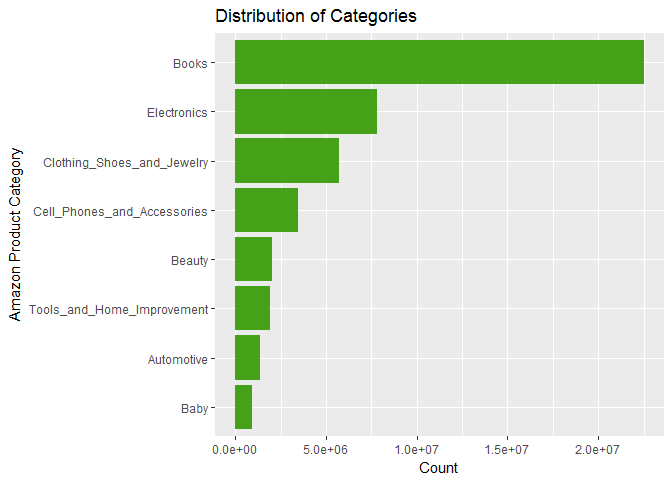

##### 3.4.3 Distribution of Prices

The distribution of product prices is heavily skewed. 1.6 million products do not have price values and for the non-nll values, the median price is $13.92, mean is $33.99 with max value of $1000. The products have a long tail in terms of prices

| Min. | 1st Qu. | Median | Mean | 3rd Qu. | Max. | NA’s |
| --- | --- | --- | --- | --- | --- | --- |
| 0 | 7.07 | 13.92 | 33.99 | 29.7 | 1000 | 1676592 |

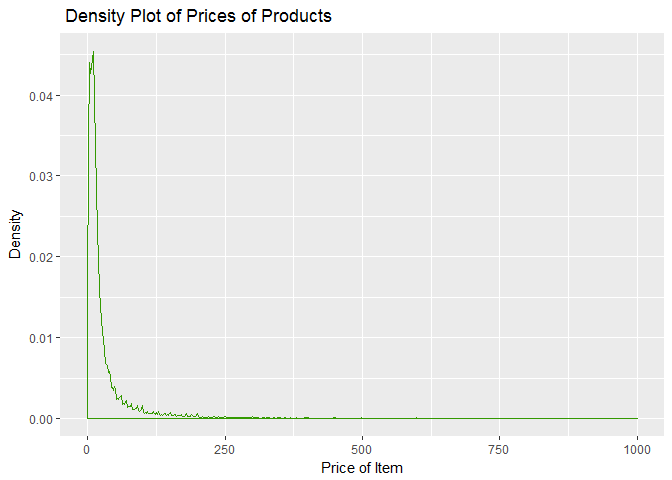

Now let’s examine the distribution of some of the more interesting individual categories, let’s look at books and electronics

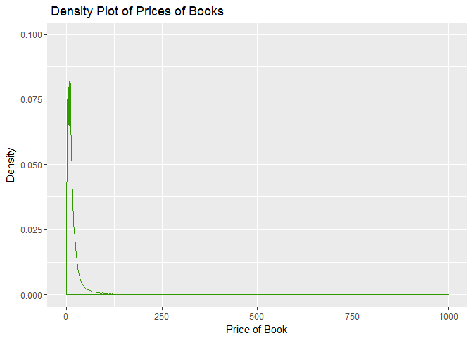

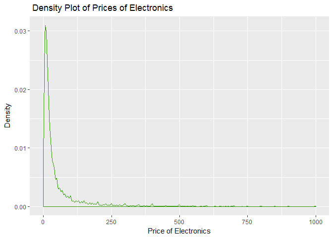

Somewhat surprising, at first glance, is the price distribution of electronics and how similar it is to the price distribution of books. However, if we look at the axis we notice that “cheap” electronics are only 3% of the density while “cheap” books are about 10% of the density. Which makes sense as we would expect on average the cost of electronics to be more than the cost of books. One extra piece of information we can gleam is the overall shape of the distributions, this looks obviously not standard normal, but possibly in the gamma family.

##### 3.4.4 Distribution of per user Ratings

The below chart shows that 55% of the entire reviewer base in data set provides only 1 review rating, 73% of the reviewer base provides less than 2 reviews and 90% of the base provides less than 5 reviews. However there are active reviewers with one reviewer providing **43,202 reviews** and top 10 reviewers with more than 4000 reviews each.

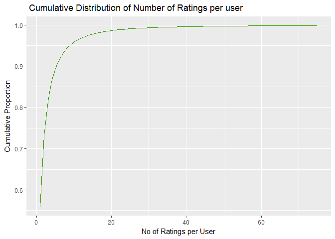

Top 10 reviewers

| uid | reviews |
| --- | --- |
| A14OJS0VWMOSWO | 43202 |
| AFVQZQ8PW0L | 28816 |
| A2F6N60Z96CAJI | 6121 |
| A320TMDV6KCFU | 5955 |
| A2OJW07GQRNJUT | 5444 |
| A328S9RN3U5M68 | 5261 |
| A1S3C5OFU508P3 | 4636 |
| A13QTZ8CIMHHG4 | 4564 |
| A1X8VZWTOG8IS6 | 4050 |
| AHD101501WCN1 | 4044 |

### 4. Executive Summary

In this summary, we hope to provide an accurate and non-technical description of our most important findings. Some of which we have already shown, as even in the preprocessing and initial visualzation stage, we were able to see some interesting patterns, such as the distribution of prices, ratings, and reviews, Which we found interesting and elaborated upon earlier. The following graphs are meant to shed some light on the “big picture” of our dataset while our main analysis goes into detail to examine both the aggregate and temporal aspects of Amazon.

We begin the summary with a visualization, highlighting the growth of amazon in terms of reviews on a year over year basis. We’ve also plotted the stock price so we can compare the two metrics of “growth”. We note that for 2014 there is only 6 months, so that explains the “drop”.

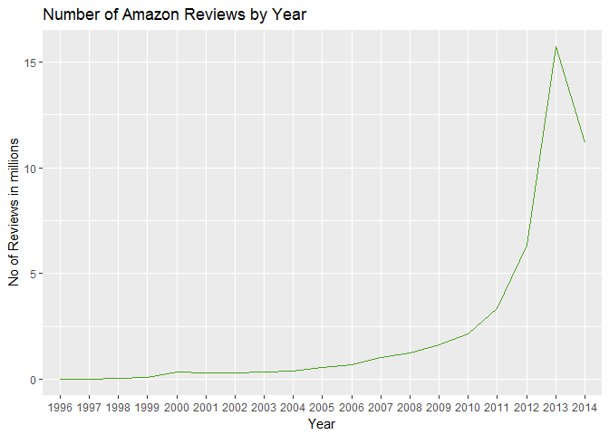

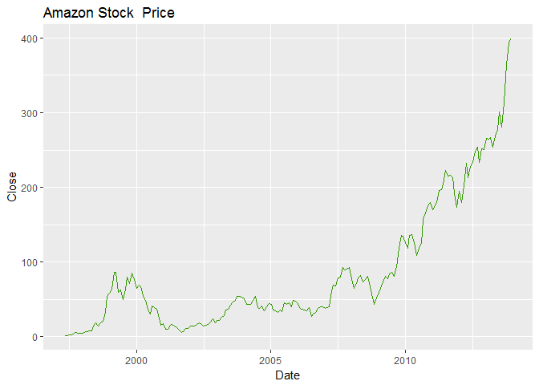

As we can see they have similar increasing trends, with the reviews being much smoother of course. So we can see that amazon is growing both from a fundamental standpoint in terms of items sold and from a market standpoint in terms of stock price.

Let’s take a look at a more aggregate view. Here is the average rating by Product Category.

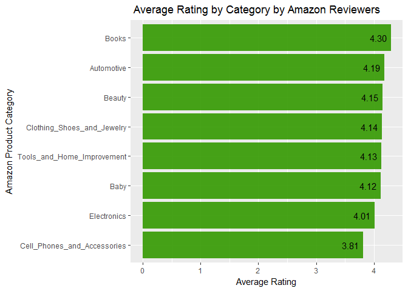

As you can see the average ratings tend to skew to the higher side. This is an interesting finding as we can begin to ask questions beyond EDA such as if we can predict ratings, or more causal questions like why are ratings skewed in such a way. Also, the rating for books is highest and cell phones and accessories is the lowest. But overall, the ratings for different categories are in a narrow range. More importantly, the fact that the ratings are all in a narrow and high range shows that Amazon has been a reliable retailer that people refer to.

These are just some key visualizations, which in conjunction with the plots found in part 3 form a good foundation for further exploration.

### 5. Main Analysis

Our main analysis focuses on the temporal and aggregate properties of the Amazon dataset. We begin with the Average Price by Category

#### 5.1 Average Price by Category

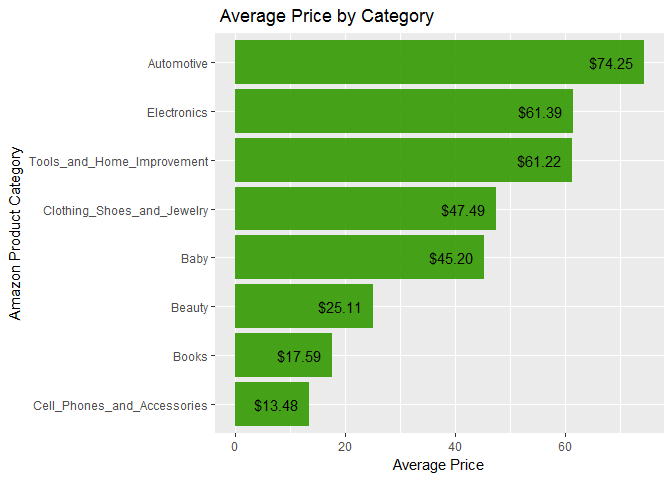

This visualization reaffirms some intuitions you might have about the dataset. On average, automotive parts are probably going to be more expensive than books. But where we can draw insights is from the not so obvious relationships. Such as Baby products being more expensive than beauty products (in expectation). And tools being the same cost as modern electronics. Another interesting fact is that books and cell-phones and accessories are the lowest although they had the best and worst ratings, respectively from the average rating plot.

#### 5.2 Monthly Trend in Reviews (across Years)

We now examine a temporal trend. How do the number of reviews change throughout the year? As we can see, in the summer the number of reviews drops substantially. This is an interesting find, and raises many questions. The obvious being why? And the not so obvious being is there something Amazon can do to prepare for lower demand?

December, March and January are the highest, August and September are the lowest. December and January are holiday seasons, March is the beginning of spring, and August and September are surprisingly low, although we expect to have back to school purchases.

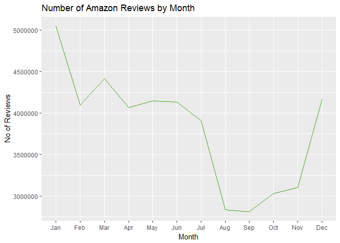

#### 5.3 Average Ratings by Month (across Years)

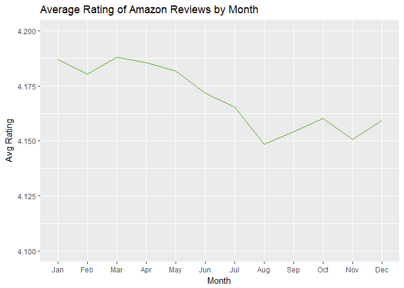

#### 5.4 Average Ratings by Year

We are also interested in finding out if there is an correlation between the “average rating” of the reviews in dataset to the country’s mood as indicated by Consumer Sentiment Index (University of Michigan). The gray periods indicate recessionary periods in US. The top chart shows the swing in ratings and the bottom chart indicates the sentiment index.

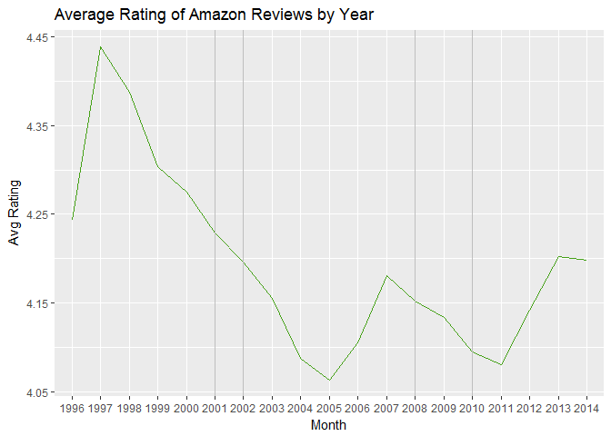

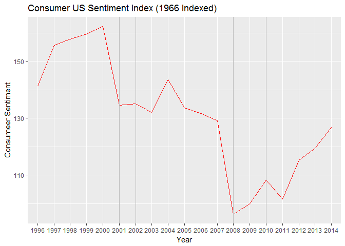

#### 5.5 Average rating of item with extreme price

Here is a finding we thought would be interesting to investigate. Is there a sort of buyer’s remorse for highly priced items? I.e. are consumers who purchased highly priced items more critical in their ratings? Here we consider items whose prices are greater than $500 Before viewing, we suggest you go back and look at the average_rating per category graph found in the executive summary. And think about what you expect the answer to be.

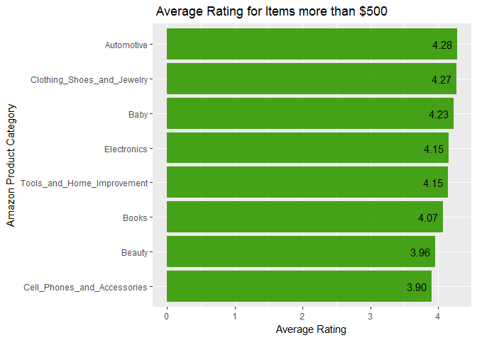

As we can see the idea of “Buyer’s Remorse” doesn’t seem to be present in the data. As the average rating is just about equal to the average rating for all products

#### 5.6 Weekly Trend in Reviews (across days of week)

In this part, we study the customer review patterns on different days of the week. We start by investigating on which days of the week the customers write more reviews. Based on the data, people write most reviews on Mondays and Tuesdays and least over the weekend. In other words, people spend less time on writing reviews over the weekend, and on Monday and Tuesday, the first days of the week to start the work, they write most reviews.

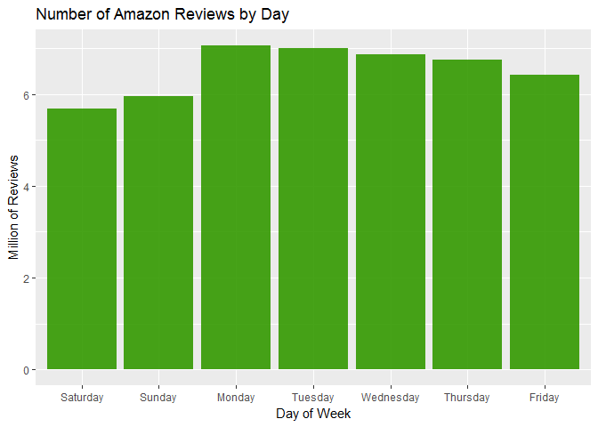

We then look into the average ratings of the customers on different days of the week. The plot below shows that the average rating is not sensitive to the day of week.

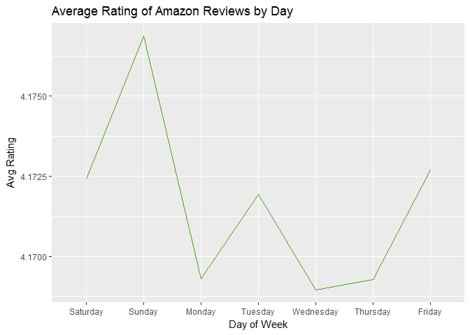

We also look into the average price of items reviewed on different days. Again, the graph shows that average price of the items purchased does not depend on the day pf week.

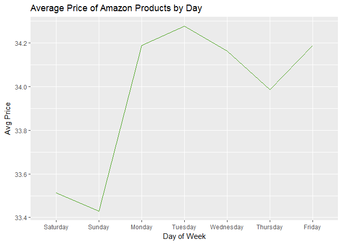

#### 5.7 Investigating most and least popular items

In this section, we study the most and the least popular items. First, we look into all the items with 5 star rating and group them by the product title. Then we rank them by sorting them based on the count. Based on the table below, the most popular item was a book called “The Hunger Games (The Hunger Games, Book 1)” with more than 16,000 5-star reviews. Among the top 10 most popular items, 4 belong to books category, 5 belong to electronics, and one belongs to cell phones and accessories category.Two of Hunger Games books are among the top 10.

| title | Category | count | ave_price |
| --- | --- | --- | --- |
| The Hunger Games (The Hunger Games, Book 1) | Books | 16492 | 4.99 |
| Kindle Fire HD 7“, Dolby Audio, Dual-Band Wi-Fi, 16 GB | Electronics | 12765 | 199.00 |
| Otterbox Defender Series Hybrid Case & Holster for iPhone 4 & 4S - Retail Packaging - Sun Yellow/Gunmetal Grey | Cell_Phones_and_Accessories | 11454 | 49.99 |
| SanDisk Ultra 64GB MicroSDXC Class 10 UHS Memory Card Speed Up To 30MB/s With Adapter, Frustration-Free Packaging - SDSDQU-064G-AFFP-A | Electronics | 10674 | 36.79 |
| Mediabridge ULTRA Series HDMI Cable (6 Feet) - High-Speed Supports Ethernet, 3D and Audio Return [Newest Standard] | Electronics | 10637 | 8.99 |
| The Book Thief | Books | 9529 | 6.99 |
| AmazonBasics High-Speed HDMI Cable - 15 Feet ( 4.6 Meters) Supports Ethernet | Electronics | 8481 | 11.99 |
| Mockingjay (The Final Book of The Hunger Games) | Books | 8356 | 6.99 |
| Google Chromecast HDMI Streaming Media Player | Electronics | 8281 | 34.49 |
| Sycamore Row | Books | 8073 | 10.49 |

| title | Category | count | ave_price |
| --- | --- | --- | --- |
| Fifty Shades of Grey: Book One of the Fifty Shades Trilogy | Books | 5775 | 4.990000 |
| To Train Up a Child | Books | 2970 | 4.384579 |
| Allegiant (Divergent, #3) | Books | 2703 | 6.990000 |
| Delton Platinum USB 30-Pin Data Cable for iPhone 3GS/4/4S and iPod | Cell_Phones_and_Accessories | 2088 | 7.950000 |
| Telebrands Pocket Hose, 50-Feet | Tools_and_Home_Improvement | 1758 | 14.240000 |
| Gone Girl | Books | 1724 | 8.520000 |
| Google Chromecast HDMI Streaming Media Player | Electronics | 1648 | 34.490000 |
| LifeProof Case for iPhone 4/4S - Retail Packaging - Purple | Cell_Phones_and_Accessories | 1454 | 74.990000 |
| Otterbox Defender Series Hybrid Case & Holster for iPhone 4 & 4S - Retail Packaging - Sun Yellow/Gunmetal Grey | Cell_Phones_and_Accessories | 1441 | 49.990000 |
| iPhone 4 / 4S Anti-Glare, Anti-Scratch, Anti-Fingerprint - Matte Finishing Screen Protector | Cell_Phones_and_Accessories | 1322 | 0.500000 |

#### 5.8 Number of Reviews per Category

Another interesting pattern is that the number of reviewers for books dominates the number of reviewers in other categories, as shown in the graph below. The ones who read more are the ones who write more. Baby products are reviewed the least. Perhaps families with babies are too busy to write reviews.

[figure not shown]

### 6. Conclusion

The challenge in this project was not only the size of data or the preprocessing involved. But also being able to draw interesting conclusions and find insight from the graphs we created. Finally, often times our intuition would have us think of an answer before we examined the data, only to find the data itself tells another story.

### 7. Extras

We developed a shiny app, which can be found here. It may take some time to load, and if you’re viewing this in Rstudio you’ll have to view it in browser. But it is a fun exploratory tool for finding books, ratings, and titles. It’s a scatterplot with a tooltip that allows for filtering. You can hover over points in the scatter plot to find the title, average rating, and average price of that particular book

[interactive chart not shown]

[Our Shiny App](https://mdiamore.shinyapps.io/edav-project2/)